# nano lab notebook: the Word Hunt hero seat

**What this is.** One executable record of the ~11M-parameter `nano/` policy: how it is built (architecture), what it is trained on and how (data, training), how it acts at match time (inference), what its play actually looks like (sample trajectories), and the numbers behind the three claims on the slide (`docs/talk-nano-slide.md`): gate, league, live learning.

Every figure below is produced by this notebook from the code in `nano/` and the artifacts in `nano/results/` and `nano/checkpoints/d6_s0.pt`. Cells that say **live** re-run something small on this machine (CPU) so the notebook stays honest about what the code does today; cells that say **recorded** read the JSON written by the real runs.

Re-render from the repo root:

```
.venv/bin/python -m jupyter nbconvert --execute --to html --output lab_notebook.html nano/lab_notebook.ipynb
```

| section | source of truth |
| --- | --- |
| 1. Architecture | `nano/model.py` |
| 2. Data and labels | `nano/data.py`, `nano/solver.py` |
| 3. Training | `nano/train.py`, `nano/results/train_d6_s0.json` (recorded) + a live smoke run |
| 4. Inference | `nano/seat.py`, `nano/policy.py` |
| 5. Sample trajectories | `nano/rollout.py` instrumented |
| 6. Gate and league | `nano/gate.py`, `nano/results/gate_d6_s0.json`, `docs/league.json` |
| 7. Live learning | `nano/learn.py`, `nano/results/live_learning_curve.md` |

```python
import json, math, os, re, sys, time
from pathlib import Path

# run from the repo root so `import nano.*` and the data/ paths resolve
root = Path.cwd()
while not (root / "nano" / "model.py").exists() and root != root.parent:
    root = root.parent
os.chdir(root)
sys.path.insert(0, str(root))
print("repo root:", root)

import numpy as np
import torch
import matplotlib
import matplotlib.pyplot as plt
from matplotlib.patches import FancyArrowPatch

torch.set_num_threads(4)
torch.manual_seed(0)
plt.rcParams.update({"figure.dpi": 110, "axes.grid": True, "grid.alpha": 0.3, "axes.spines.top": False, "axes.spines.right": False})

from nano.solver import Solver, NEIGHBORS, MAX_LEN, MIN_LEN, path_word, score_word, load_common_ranks
from nano.data import (annotate, word_weight, letter_distribution, random_board, generate, legal_moves, TYPES,
                       sample_path, rows_from_info, pack)
from nano.model import (NanoAgent, ModelConfig, encode, to_device, compute_loss, SEQ_LEN, N_TILES, VOCAB_SIZE,
                        TOK_CLS, TOK_LETTER, TOK_TILE, TOK_LEN, _SEGS)
from nano.policy import StudentPolicy, RandomSwiper, board_to_ids
from nano.seat import NanoSeat, bench
from nano.rollout import play, summarize
from nano.train import pre_encode, split, DeviceData, train as train_loop, evaluate
from nano.device import torch_device

CKPT = "nano/checkpoints/d6_s0.pt"
CPU = torch.device("cpu")

t0 = time.time()
solver = Solver()
ranks = load_common_ranks(valid=solver.word_set)
letter_p = letter_distribution(solver.words)
model, extra = NanoAgent.load(CKPT)
model.eval()
tr_info = extra.get("train", {})
print(f"solver: {len(solver.words)} enable1 words of length {MIN_LEN}-{MAX_LEN}; {len(ranks)} of them have a common-word rank")
print(f"checkpoint: {CKPT}  depth {model.cfg.depth}  d_model {model.cfg.d_model}  params {model.n_params()/1e6:.2f}M  "
      f"trained {tr_info.get('steps')} steps on {tr_info.get('device')} in {tr_info.get('wall_sec',0)/60:.0f} min")
print(f"setup {time.time()-t0:.1f}s")
```

```
repo root: /Users/bourkefloydiv/projects/deepmind-gradient-hackathon-2026-main
```

```
solver: 80272 enable1 words of length 3-8; 14449 of them have a common-word rank
checkpoint: nano/checkpoints/d6_s0.pt  depth 6  d_model 384  params 10.99M  trained 17278 steps on mps in 30 min
setup 0.2s
```

## 1. Architecture

`nano/model.py` is a pre-norm transformer with a single dial, `depth`: width (= 64 \cdot \text{depth}), heads (= \text{depth}) (head dim 64), MLP 4x. Depth 6 is what plays on stage (10.99M parameters).

The input is a fixed 26-token sequence. There is no dictionary anywhere in the forward pass: the network sees the 16 letters, where they sit on the grid, and the tiles it has already traced.

| position | token | embeddings summed into it |
| --- | --- | --- |
| 0 | `[CLS]` | token + segment `CLS` + position |
| 1..16 | tile (i) | letter id + segment `TILE` + grid position (i) |
| 17 | path length | `LEN+k` token + segment `LEN` + position |
| 18..25 | path step (j) | tile-index token + **that tile's letter** + segment `PATH` + step position (padded, masked out) |

Three heads read the `[CLS]` state:

- `target_logits (B,16)` — a pointer: (\langle q(\text{cls}), k(h_i)\rangle / \sqrt{d}) over the 16 tile states, with every tile that is not adjacent to the path head (or already used) masked to (-\infty). On an empty path it is "where to start".
- `type_logits (B,3)` — `{extend, submit, abort}`.
- `value_logit (B,)` — (P(\text{this prefix still completes to a word})); the "is this going somewhere" signal, and the escalation trigger for the stretch Gemma hand-off.

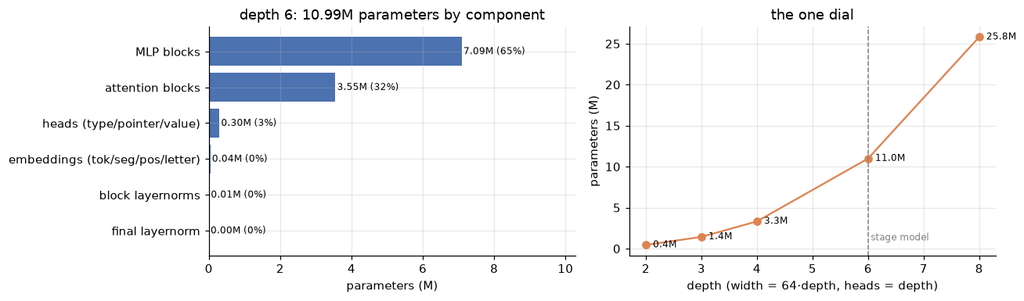

```
vocab 53 tokens; seq len 26 ; segments 4
Block(
  (ln1): LayerNorm((384,), eps=1e-05, elementwise_affine=True, bias=True)
  (attn): MultiheadAttention(
    (out_proj): NonDynamicallyQuantizableLinear(in_features=384, out_features=384, bias=True)
  )
  (ln2): LayerNorm((384,), eps=1e-05, elementwise_affine=True, bias=True)
  (mlp): Sequential(
    (0): Linear(in_features=384, out_features=1536, bias=True)
    (1): GELU(approximate='none')
    (2): Linear(in_features=1536, out_features=384, bias=True)
    (3): Dropout(p=0.0, inplace=False)
  )
)
```

```python
# parameter budget by component, and the depth dial
def param_breakdown(m: NanoAgent) -> dict[str, int]:
    groups = {"embeddings (tok/seg/pos/letter)": 0, "attention blocks": 0, "MLP blocks": 0, "block layernorms": 0, "heads (type/pointer/value)": 0, "final layernorm": 0}
    for name, p in m.named_parameters():
        n = p.numel()
        if name.startswith(("tok.", "seg.", "pos.", "letter.")):
            groups["embeddings (tok/seg/pos/letter)"] += n
        elif ".attn." in name:
            groups["attention blocks"] += n
        elif ".mlp." in name:
            groups["MLP blocks"] += n
        elif ".ln1." in name or ".ln2." in name:
            groups["block layernorms"] += n
        elif name.startswith(("type_head", "q_target", "k_target", "value_head")):
            groups["heads (type/pointer/value)"] += n
        elif name.startswith("ln_f"):
            groups["final layernorm"] += n
    return groups

bd = param_breakdown(model)
depths = [2, 3, 4, 6, 8]
sweep = [(d, NanoAgent(ModelConfig(depth=d)).n_params()) for d in depths]

fig, ax = plt.subplots(1, 2, figsize=(12, 3.6))
names, vals = zip(*sorted(bd.items(), key=lambda kv: -kv[1]))
ax[0].barh(names, np.array(vals) / 1e6, color="#4C72B0")
for i, v in enumerate(vals):
    ax[0].text(v / 1e6 + 0.05, i, f"{v/1e6:.2f}M ({100*v/model.n_params():.0f}%)", va="center", fontsize=8)
ax[0].set_xlabel("parameters (M)"); ax[0].set_title(f"depth {model.cfg.depth}: {model.n_params()/1e6:.2f}M parameters by component"); ax[0].invert_yaxis()
ax[0].set_xlim(0, max(vals) / 1e6 * 1.45)
ax[1].plot([d for d, _ in sweep], [n / 1e6 for _, n in sweep], "o-", color="#DD8452")
for d, n in sweep:
    ax[1].annotate(f"{n/1e6:.1f}M", (d, n / 1e6), textcoords="offset points", xytext=(6, -2), fontsize=8)
ax[1].axvline(6, ls="--", color="gray", lw=1); ax[1].text(6.05, 1, "stage model", color="gray", fontsize=8)
ax[1].set_xlabel("depth (width = 64·depth, heads = depth)"); ax[1].set_ylabel("parameters (M)"); ax[1].set_title("the one dial")
plt.tight_layout(); plt.show()

print("vocab", VOCAB_SIZE, "tokens; seq len", SEQ_LEN, "; segments", int(_SEGS.max()) + 1)
print(model.blocks[0])
```

### 1.1 What one input looks like

Below: a board, a partial path, and the 26 tokens the model sees for it. The right panel is the legality mask `tmask` that the pointer head is restricted to (green = legal next tile: adjacent to the path head and unused).

```
board 'ratehunslentgoid': 220 words, max score 126700; longest: ['sentinel', 'eluants', 'eluates', 'glenoid', 'glutens', 'instant', 'anenst', 'auntie']
```

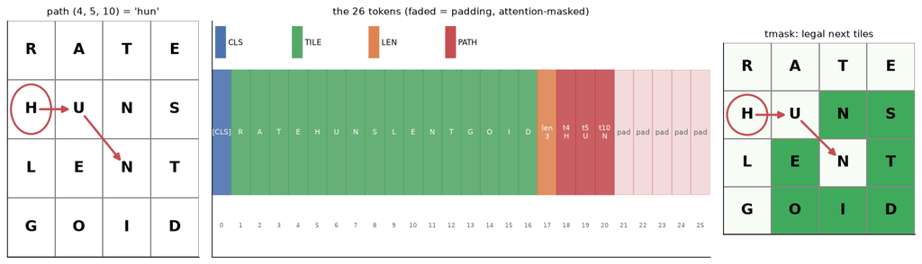

```
legal next tiles: [6, 7, 9, 11, 13, 14, 15] -> ['N', 'S', 'E', 'T', 'O', 'I', 'D']
```

```python
BOARD = "ratehunslentgoid"      # the solver's own demo board (nano/solver.py __main__)
words_on = solver.words_on(BOARD)
print(f"board {BOARD!r}: {len(words_on)} words, max score {sum(score_word(w) for w in words_on)}; longest:",
      sorted(words_on, key=lambda w: (-len(w), w))[:8])

def draw_board(ax, board: str, path=(), title=None, tile_colors=None, cmap="Greens", vmin=None, vmax=None, annotate_vals=None, arrow_color="#C44E52"):
    board = board.lower()
    ax.set_xlim(-0.5, 3.5); ax.set_ylim(3.5, -0.5); ax.set_xticks([]); ax.set_yticks([]); ax.grid(False)
    if tile_colors is not None:
        tc = np.asarray(tile_colors, dtype=float).reshape(4, 4)
        ax.imshow(tc, cmap=cmap, vmin=vmin if vmin is not None else np.nanmin(tc), vmax=vmax if vmax is not None else max(np.nanmax(tc), 1e-9), extent=(-0.5, 3.5, 3.5, -0.5))
    for i in range(16):
        r, c = divmod(i, 4)
        ax.add_patch(plt.Rectangle((c - 0.5, r - 0.5), 1, 1, fill=False, ec="#888", lw=1))
        ax.text(c, r - 0.12 if annotate_vals is not None else r, board[i].upper(), ha="center", va="center", fontsize=15, fontweight="bold", color="black")
        if annotate_vals is not None:
            ax.text(c, r + 0.3, annotate_vals[i], ha="center", va="center", fontsize=7, color="#333")
    for a, b in zip(path, path[1:]):
        (ra, ca), (rb, cb) = divmod(a, 4), divmod(b, 4)
        ax.add_patch(FancyArrowPatch((ca, ra), (cb, rb), arrowstyle="-|>", mutation_scale=14, lw=2.2, color=arrow_color, shrinkA=9, shrinkB=9))
    if path:
        r, c = divmod(path[0], 4)
        ax.add_patch(plt.Circle((c, r), 0.42, fill=False, ec=arrow_color, lw=2))
    if title:
        ax.set_title(title, fontsize=10)

# a partial path spelling "hun" (h=5, u=6, n=7 on this board? find it with the solver's own path finder)
from nano.data import word_paths
demo_path = word_paths(BOARD, "hun")[0]
enc = encode(board_to_ids(BOARD)[None], np.array([list(demo_path) + [-1] * (MAX_LEN - len(demo_path))], np.int8), np.array([len(demo_path)], np.uint8))

fig = plt.figure(figsize=(13, 3.8))
gs = fig.add_gridspec(1, 3, width_ratios=[1, 2.6, 1])
ax0 = fig.add_subplot(gs[0]); draw_board(ax0, BOARD, demo_path, title=f"path {demo_path} = '{path_word(BOARD, demo_path)}'")
ax1 = fig.add_subplot(gs[1]); ax1.grid(False)
seg_names = ["CLS", "TILE", "LEN", "PATH"]
seg_col = np.array(["#4C72B0", "#55A868", "#DD8452", "#C44E52"])
ids, segs, attn, letter = enc["ids"][0], enc["segs"][0], enc["attn"][0], enc["letter"][0]
for p in range(SEQ_LEN):
    tok = ids[p]
    if tok == TOK_CLS: lab = "[CLS]"
    elif TOK_LETTER <= tok < TOK_TILE: lab = chr(97 + tok - TOK_LETTER).upper()
    elif TOK_TILE <= tok < TOK_LEN: lab = f"t{tok - TOK_TILE}\n{chr(97 + letter[p]).upper()}"
    elif tok >= TOK_LEN: lab = f"len\n{tok - TOK_LEN}"
    else: lab = "pad"
    ax1.add_patch(plt.Rectangle((p, 0), 1, 1, color=seg_col[segs[p]], alpha=0.9 if attn[p] else 0.2))
    ax1.text(p + 0.5, 0.5, lab, ha="center", va="center", fontsize=7, color="white" if attn[p] else "#666")
    ax1.text(p + 0.5, -0.25, str(p), ha="center", va="center", fontsize=6, color="#666")
ax1.set_xlim(0, SEQ_LEN); ax1.set_ylim(-0.5, 1.4); ax1.set_yticks([]); ax1.set_xticks([])
for k, nm in enumerate(seg_names):
    ax1.add_patch(plt.Rectangle((k * 4 + 0.2, 1.1), 0.5, 0.25, color=seg_col[k])); ax1.text(k * 4 + 0.85, 1.22, nm, fontsize=8, va="center")
ax1.set_title("the 26 tokens (faded = padding, attention-masked)", fontsize=10)
ax2 = fig.add_subplot(gs[2]); draw_board(ax2, BOARD, demo_path, title="tmask: legal next tiles", tile_colors=enc["tmask"][0].astype(float), vmin=0, vmax=1.6)
plt.tight_layout(); plt.show()
print("legal next tiles:", [int(i) for i in np.flatnonzero(enc['tmask'][0])], "->", [BOARD[i].upper() for i in np.flatnonzero(enc['tmask'][0])])
```

### 1.2 What the heads say, and where `[CLS]` looks

Same input through the trained checkpoint: the three head outputs, then the last block's attention from `[CLS]` onto the 16 tile positions, one panel per head. The pointer is hard-masked to the legal tiles, so all of its mass sits on neighbours of the path head.

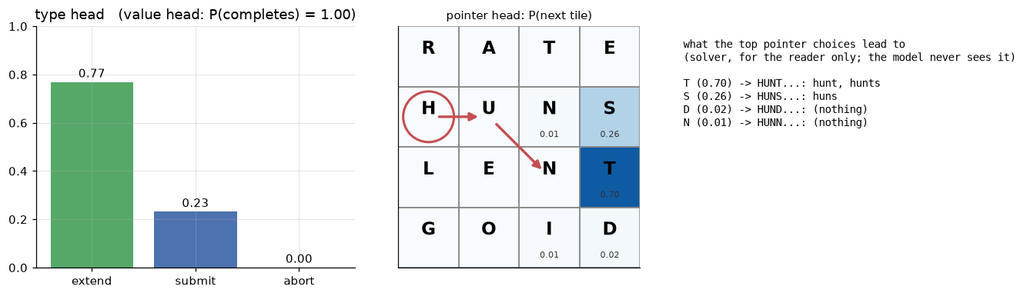

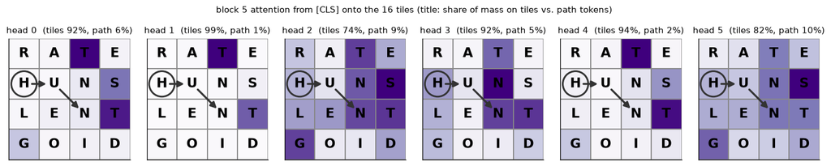

```python
@torch.no_grad()
def forward_with_attention(m: NanoAgent, enc: dict) -> tuple[dict, list[torch.Tensor]]:
    b = to_device(enc, CPU)
    ids, segs, attn = b["ids"], b["segs"], b["attn"]
    B, L = ids.shape
    pos = torch.arange(L).unsqueeze(0)
    x = m.tok(ids) + m.seg(segs) + m.pos(pos)
    letter = b["letter"]
    x = x + m.letter(torch.where(letter >= 0, letter, torch.full_like(letter, 26)))
    kpm = ~attn
    weights = []
    for blk in m.blocks:
        h = blk.ln1(x)
        a, w = blk.attn(h, h, h, key_padding_mask=kpm, need_weights=True, average_attn_weights=False)
        weights.append(w)  # (B, heads, L, L)
        x = x + a
        x = x + blk.mlp(blk.ln2(x))
    x = m.ln_f(x)
    cls = x[:, 0]
    ht = x[:, 1:1 + N_TILES]
    tl = (m.k_target(ht) * m.q_target(cls).unsqueeze(1)).sum(-1) / math.sqrt(x.shape[-1])
    tl = tl.masked_fill(~b["tmask"], float("-inf"))
    return {"type_logits": m.type_head(cls), "target_logits": tl, "value_logit": m.value_head(cls).squeeze(-1)}, weights

out, W = forward_with_attention(model, enc)
type_p = torch.softmax(out["type_logits"], -1)[0].numpy()
tgt_p = np.nan_to_num(torch.softmax(out["target_logits"], -1)[0].numpy())
value = float(torch.sigmoid(out["value_logit"])[0])

fig, ax = plt.subplots(1, 3, figsize=(13, 3.6))
ax[0].bar(TYPES, type_p, color=["#55A868", "#4C72B0", "#C44E52"]); ax[0].set_ylim(0, 1); ax[0].set_title(f"type head   (value head: P(completes) = {value:.2f})")
for i, v in enumerate(type_p): ax[0].text(i, v + 0.02, f"{v:.2f}", ha="center")
draw_board(ax[1], BOARD, demo_path, title="pointer head: P(next tile)", tile_colors=tgt_p, cmap="Blues", vmin=0, vmax=max(tgt_p.max(), 1e-6) * 1.2, annotate_vals=[f"{p:.2f}" if p > 0.005 else "" for p in tgt_p])
# which words do those next tiles lead to?
top = np.argsort(-tgt_p)[:4]
lines = []
for t in top:
    if tgt_p[t] < 0.01: continue
    pre = path_word(BOARD, demo_path + (int(t),))
    conts = sorted([w for w in words_on if w.startswith(pre)], key=lambda w: ranks.get(w, 10**6))[:5]
    lines.append(f"{BOARD[t].upper()} ({tgt_p[t]:.2f}) -> {pre.upper()}...: {', '.join(conts) or '(nothing)'}")
ax[2].axis("off"); ax[2].text(0, 0.95, "what the top pointer choices lead to\n(solver, for the reader only; the model never sees it)\n\n" + "\n".join(lines), va="top", fontsize=9, family="monospace")
plt.tight_layout(); plt.show()

# attention from [CLS] onto tile positions, last block, per head
last = W[-1][0]  # (heads, L, L)
n_heads = last.shape[0]
fig, ax = plt.subplots(1, n_heads, figsize=(2.2 * n_heads, 2.5))
for h in range(n_heads):
    w_cls = last[h, 0].numpy()                     # attention row of [CLS]
    tiles = w_cls[1:1 + N_TILES]
    draw_board(ax[h], BOARD, demo_path, title=f"head {h}  (tiles {tiles.sum():.0%}, path {w_cls[18:].sum():.0%})", tile_colors=tiles, cmap="Purples", vmin=0, vmax=max(tiles.max(), 1e-6), arrow_color="#333")
fig.suptitle(f"block {len(W)-1} attention from [CLS] onto the 16 tiles (title: share of mass on tiles vs. path tokens)", fontsize=10, y=1.03)
plt.tight_layout(); plt.show()
```

## 2. Data and labels

Word Hunt gives what the AndroidWorld student never had: an exact oracle (the solver) and infinite boards. `nano/data.py` turns that into **soft targets** rather than one-hot demonstrations, the "hindsight soft targets" rung that beat plain BC in the prior work (`docs/nanoagent-handoff.md`).

The generative story behind a label: a player samples a word on the board with probability (\propto) `word_weight(word)` (common words heavy; enable1-only words at weight 0.01), and traces one of its paths tile by tile. For every prefix along the way the label is the *posterior of that process*:

- `target_dist[tile]` (\propto) mass of completions continuing through `tile`;
- `type_dist = [extend, submit, abort]` (\propto) `[mass of longer completions, weight of the prefix itself as a word, 0]`;
- `value = 1`.

Dead prefixes (a legal move no word continues) are mined beside the sampled ones with `type = abort`, `value = 0`, and an all-zero pointer row that `soft_ce` skips.

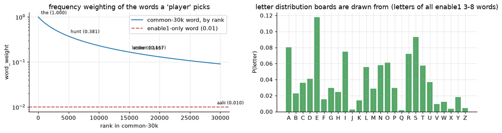

```
14449 of 80272 playable words carry a common rank; the other 65823 share weight 0.01 each
```

```python
fig, ax = plt.subplots(1, 2, figsize=(12, 3.4))
r = np.arange(0, 30000)
ax[0].semilogy(r, 1.0 / (1.0 + r / 3000.0), label="common-30k word, by rank")
ax[0].axhline(0.01, color="#C44E52", ls="--", label="enable1-only word (0.01)")
ax[0].set_xlabel("rank in common-30k"); ax[0].set_ylabel("word_weight"); ax[0].set_title("frequency weighting of the words a 'player' picks"); ax[0].legend()
for w in ["the", "hunt", "lantern", "stoke", "aalii"]:
    if w in solver.word_set:
        ax[0].annotate(f"{w} ({word_weight(w, ranks):.3f})", (ranks.get(w, 29000), word_weight(w, ranks)), textcoords="offset points", xytext=(5, 5), fontsize=8)
ax[1].bar([chr(97 + i).upper() for i in range(26)], letter_p, color="#55A868")
ax[1].set_title("letter distribution boards are drawn from (letters of all enable1 3-8 words)"); ax[1].set_ylabel("P(letter)")
plt.tight_layout(); plt.show()
n_common = sum(1 for w in solver.words if w in ranks)
print(f"{n_common} of {len(solver.words)} playable words carry a common rank; the other {len(solver.words)-n_common} share weight 0.01 each")
```

### 2.1 The soft targets on one board

`annotate(board)` walks the trie over the board once and returns, for every live prefix, its weight as a word and the completion mass through each next tile. Below: the start-tile distribution (empty prefix), then the targets for two prefixes of increasing length. Note how `submit` mass appears once the prefix is itself a word.

```
220 distinct words along 302 word paths -> 465 live prefixes on 'ratehunslentgoid'
```

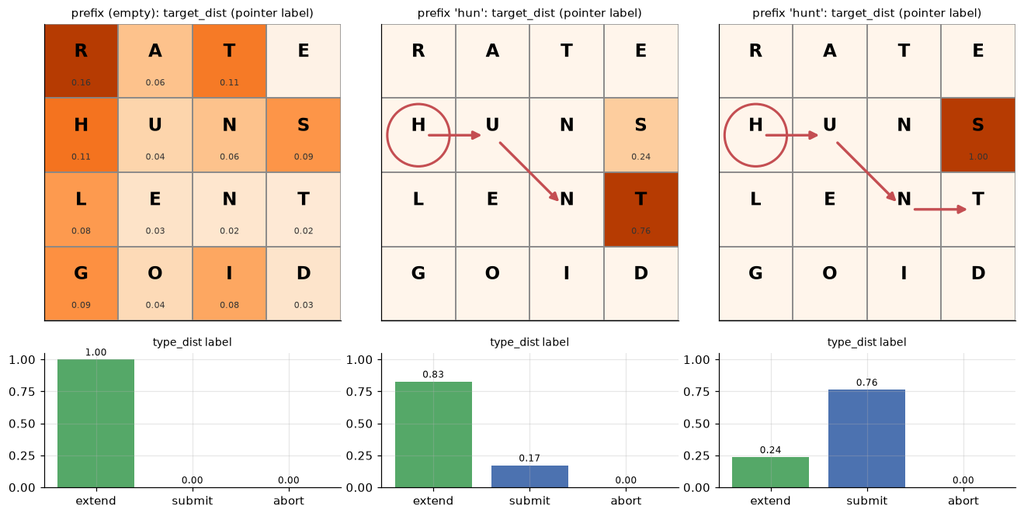

```
start-tile mass (top 6): R@0=0.16, H@4=0.11, T@2=0.11, G@12=0.09, S@7=0.09, L@8=0.08
6 sampled 'player' words: ['neon', 'huns', 'nuts', 'uns', 'tunes', 'end']
```

```python
info, n_word_paths = annotate(BOARD, solver, ranks)
print(f"{len(words_on)} distinct words along {n_word_paths} word paths -> {len(info)} live prefixes on {BOARD!r}")

def label_for(prefix: tuple[int, ...]):
    w_word, kids = info[prefix]
    tgt = np.zeros(16); ext = 0.0
    for j, m in kids.items():
        tgt[j] = m; ext += m
    if ext > 0: tgt /= ext
    ty = np.array([ext, w_word, 0.0]); ty /= ty.sum()
    return tgt, ty

prefixes = [(), word_paths(BOARD, "hun")[0], word_paths(BOARD, "hunt")[0]]
fig, ax = plt.subplots(2, len(prefixes), figsize=(4 * len(prefixes), 6.2), gridspec_kw={"height_ratios": [3, 1.2]})
for k, p in enumerate(prefixes):
    tgt, ty = label_for(p)
    nm = f"'{path_word(BOARD, p)}'" if p else "(empty)"
    draw_board(ax[0, k], BOARD, p, title=f"prefix {nm}: target_dist (pointer label)", tile_colors=tgt, cmap="Oranges", vmin=0, vmax=max(tgt.max(), 1e-6) * 1.2, annotate_vals=[f"{v:.2f}" if v > 0.005 else "" for v in tgt])
    ax[1, k].bar(TYPES, ty, color=["#55A868", "#4C72B0", "#C44E52"]); ax[1, k].set_ylim(0, 1.05); ax[1, k].set_title("type_dist label", fontsize=9)
    for i, v in enumerate(ty): ax[1, k].text(i, v + 0.03, f"{v:.2f}", ha="center", fontsize=8)
plt.tight_layout(); plt.show()

# the mass behind each start tile, in words
starts = info[()][1]
tot = sum(starts.values())
print("start-tile mass (top 6):", ", ".join(f"{BOARD[t].upper()}@{t}={m/tot:.2f}" for t, m in sorted(starts.items(), key=lambda kv: -kv[1])[:6]))
rng_demo = np.random.default_rng(1)
print("6 sampled 'player' words:", [path_word(BOARD, sample_path(info, rng_demo)) for _ in range(6)])
```

### 2.2 A small dataset, live

`generate()` is what `python -m nano.data --boards 200000` runs with workers; here 300 boards on one worker so the shapes and statistics are visible. The stage checkpoint trained on 200k boards → 4.96M samples (about 25 per board).

```
300 boards -> 7620 samples (25.4/board) in 0.3s; dead fraction 0.22; mean submit mass 0.225
{'board': ((7620, 16), 'uint8'), 'path': ((7620, 8), 'int8'), 'plen': ((7620,), 'uint8'), 'target': ((7620, 16), 'float16'), 'ptype': ((7620, 3), 'float16'), 'value': ((7620,), 'uint8'), 'bid': ((7620,), 'int32')}
```

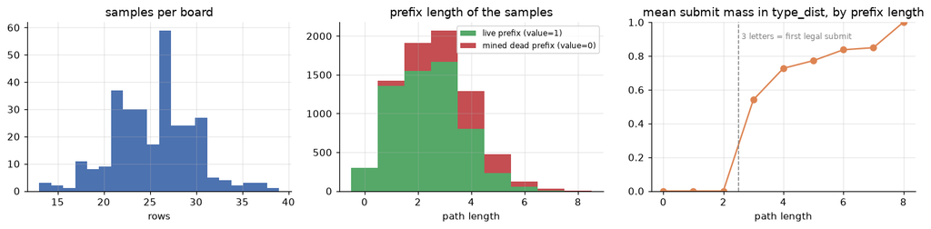

```python
t0 = time.time()
small = generate(300, n_paths=6, dead_frac=0.3, min_words=15, seed=123, workers=1)
n = len(small["value"]); per_board = np.bincount(small["bid"])
print(f"300 boards -> {n} samples ({n/300:.1f}/board) in {time.time()-t0:.1f}s; "
      f"dead fraction {1-small['value'].mean():.2f}; mean submit mass {small['ptype'][:,1].astype(float).mean():.3f}")
print({k: (v.shape, str(v.dtype)) for k, v in small.items()})

plen = small["plen"].astype(int); live = small["value"] == 1
fig, ax = plt.subplots(1, 3, figsize=(13, 3.3))
ax[0].hist(per_board, bins=20, color="#4C72B0"); ax[0].set_title("samples per board"); ax[0].set_xlabel("rows")
bins = np.arange(0, MAX_LEN + 2) - 0.5
ax[1].hist([plen[live], plen[~live]], bins=bins, stacked=True, color=["#55A868", "#C44E52"], label=["live prefix (value=1)", "mined dead prefix (value=0)"])
ax[1].set_title("prefix length of the samples"); ax[1].set_xlabel("path length"); ax[1].legend(fontsize=8)
sub = small["ptype"][:, 1].astype(float)
means = [sub[live & (plen == k)].mean() if (live & (plen == k)).any() else np.nan for k in range(MAX_LEN + 1)]
ax[2].plot(range(MAX_LEN + 1), means, "o-", color="#DD8452"); ax[2].set_ylim(0, 1); ax[2].set_title("mean submit mass in type_dist, by prefix length"); ax[2].set_xlabel("path length")
ax[2].axvline(MIN_LEN - 0.5, ls="--", color="gray", lw=1); ax[2].text(MIN_LEN - 0.4, 0.9, "3 letters = first legal submit", fontsize=8, color="gray")
plt.tight_layout(); plt.show()
```

## 3. Training

`nano/train.py` is the nanoagent recipe unchanged: soft cross-entropy on the type and pointer heads, BCE-with-logits on value (weight 0.5), AdamW ((\beta_1, \beta_2) = (0.9, 0.95)), weight decay 0.1, grad-norm clip 1.0, cosine to 10% of the peak lr, **fp32 with no AMP** (bf16 autocast only ever on CUDA, kept off so records stay comparable). Peak lr follows (3\times10^{-4},\sqrt{4/\text{depth}}) (smaller models take a larger lr). Non-finite losses are counted and skipped.

The whole dataset is tokenised once (`pre_encode`) and kept on the device as small-dtype tensors, so a step is pure indexing plus the forward/backward. Validation holds out the last 2% of *boards* (samples of a board are contiguous), so no board leaks.

### 3.1 The recorded run behind `d6_s0.pt`

`runs/d6_s0` → `nano/results/train_d6_s0.json`: depth 6, batch 256, `--budget-min 30` on the laptop's MPS. The cosine schedule is driven by the time budget, so the run finishes its anneal at exactly 30 minutes regardless of step count.

```
depth 6  params 10.99M  device mps  batch 256  peak lr 2.45e-04
17278 steps in 30.0 min = 2457 samples/s; 4.42M samples seen of 4.96M (~0.89 epochs); non-finite steps 0
loss 2.611 -> 1.069; final val: {'loss': 1.073, 'type': 0.203, 'target': 0.823, 'value': 0.095, 'type_top1': 0.935, 'target_top1': 0.767, 'value_acc': 0.964}
```

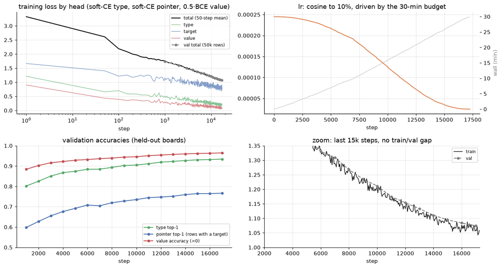

```python
T = json.load(open("nano/results/train_d6_s0.json"))
curve, vcurve = T["curve"], T["val_curve"]
steps = np.array([c["step"] for c in curve])
print(f"depth {T['depth']}  params {T['n_params']/1e6:.2f}M  device {T['device']}  batch {T['batch_size']}  peak lr {T['lr']:.2e}")
print(f"{T['steps']} steps in {T['wall_sec']/60:.1f} min = {T['samples_per_sec']:.0f} samples/s; {T['samples_seen']/1e6:.2f}M samples seen of {T['n_train']/1e6:.2f}M "
      f"(~{T['samples_seen']/T['n_train']:.2f} epochs); non-finite steps {T['nonfinite_steps']}")
print(f"loss {T['first_loss']:.3f} -> {T['final_loss']:.3f}; final val:", {k: round(v, 3) for k, v in T["val"].items() if k != "n"})

fig, ax = plt.subplots(2, 2, figsize=(13, 7))
ax[0, 0].plot(steps, [c["loss"] for c in curve], label="total (50-step mean)", color="black", lw=1.5)
for key, col in (("type", "#55A868"), ("target", "#4C72B0"), ("value", "#C44E52")):
    ax[0, 0].plot(steps, [c[key] for c in curve], label=key, color=col, alpha=0.7, lw=1)
ax[0, 0].plot([v["step"] for v in vcurve], [v["loss"] for v in vcurve], "o--", color="gray", ms=4, label="val total (50k rows)")
ax[0, 0].set_xscale("log"); ax[0, 0].set_xlabel("step"); ax[0, 0].set_title("training loss by head (soft-CE type, soft-CE pointer, 0.5·BCE value)"); ax[0, 0].legend(fontsize=8)
ax[0, 1].plot(steps, [c["lr"] for c in curve], color="#DD8452"); ax[0, 1].set_title("lr: cosine to 10%, driven by the 30-min budget"); ax[0, 1].set_xlabel("step")
ax2 = ax[0, 1].twinx(); ax2.plot(steps, [c["sec"] / 60 for c in curve], color="gray", ls=":", lw=1); ax2.set_ylabel("wall (min)", color="gray"); ax2.grid(False)
vs = [v["step"] for v in vcurve]
for key, col, lab in (("type_top1", "#55A868", "type top-1"), ("target_top1", "#4C72B0", "pointer top-1 (rows with a target)"), ("value_acc", "#C44E52", "value accuracy (>0)")):
    ax[1, 0].plot(vs, [v[key] for v in vcurve], "o-", color=col, ms=4, label=lab)
ax[1, 0].set_ylim(0.5, 1.0); ax[1, 0].set_xlabel("step"); ax[1, 0].set_title("validation accuracies (held-out boards)"); ax[1, 0].legend(fontsize=8)
ax[1, 1].plot(steps[1:], [c["loss"] for c in curve][1:], color="black", lw=1, label="train")
ax[1, 1].plot(vs, [v["loss"] for v in vcurve], "o--", color="gray", ms=4, label="val")
ax[1, 1].set_xlim(2000, T["steps"]); ax[1, 1].set_ylim(1.0, 1.35); ax[1, 1].set_xlabel("step"); ax[1, 1].set_title("zoom: last 15k steps, no train/val gap"); ax[1, 1].legend(fontsize=8)
plt.tight_layout(); plt.show()
```

**Reading it.** The pointer head carries most of the residual loss (0.82 of the 1.07 total): a soft target over several valid continuations has irreducible entropy, so top-1 of 0.77 against the argmax of the label is the better read. The type head is at 0.935 top-1 and the value head at 0.964 accuracy. Train and val sit on top of each other: with 4.4M samples seen on 4.96M available (under one epoch) there is nothing to overfit yet, so more steps or a second seed are the obvious next runs.

### 3.2 A live smoke run (CPU)

The same `train()` loop on the 300-board set from section 2, depth 4, 300 steps, batch 128, on CPU. This is what `make train-smoke` does at smaller scale; it exists here so a reader can see the loop run end to end in under a minute. The real run uses MPS (`make check-mps` first: `nano/device.py` refuses a silent CPU fallback on Apple Silicon).

```
train 6828 rows / val 792 rows
```

```
300 steps in 22.3s (1723 samples/s on CPU, 4 threads); loss 2.608 -> 1.856
model depth 4 d_model 256 params 3.32M lr 3.00e-04 batch 128 steps 300 budget 0.0 min
step 250 loss 1.9285 type 0.499 target 1.167 value 0.337 lr 4.88e-05 1723 samples/s
step 300 loss 1.8564 type 0.549 target 0.994 value 0.311 lr 3.00e-05 1736 samples/s
  val@300: loss 2.1773 type_top1 0.723 target_top1 0.520 value_acc 0.838 (n=792)
```

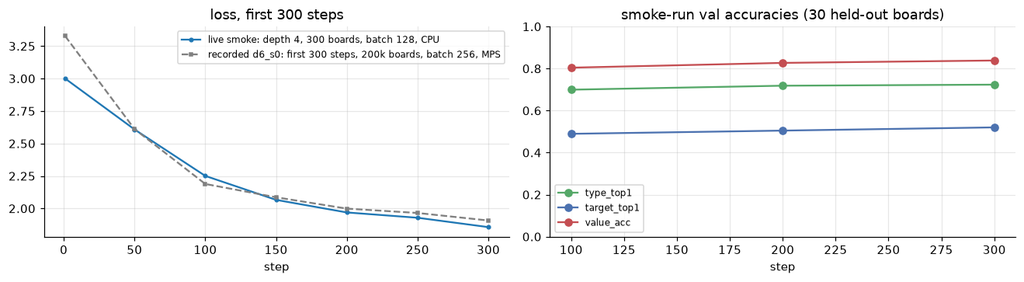

```python
enc_small = pre_encode(small)
tr_np, va_np = split(enc_small, small["bid"], 0.1)
tr, va = DeviceData(tr_np, CPU), DeviceData(va_np, CPU)
print(f"train {tr.n} rows / val {va.n} rows")
logs = []
t0 = time.time()
smoke_model, smoke_info = train_loop(tr, va, depth=4, steps=300, batch_size=128, seed=0, log=logs.append, val_every=100)
print(f"{smoke_info['steps']} steps in {smoke_info['wall_sec']:.1f}s ({smoke_info['samples_per_sec']:.0f} samples/s on CPU, {torch.get_num_threads()} threads); "
      f"loss {smoke_info['first_loss']:.3f} -> {smoke_info['final_loss']:.3f}")
print("\n".join(logs[:1] + logs[-3:]))

fig, ax = plt.subplots(1, 2, figsize=(12, 3.4))
sc = smoke_info["curve"]
ax[0].plot([c["step"] for c in sc], [c["loss"] for c in sc], "o-", ms=3, label="live smoke: depth 4, 300 boards, batch 128, CPU")
head = [c for c in curve if c["step"] <= 300]
ax[0].plot([c["step"] for c in head], [c["loss"] for c in head], "s--", ms=3, color="gray", label="recorded d6_s0: first 300 steps, 200k boards, batch 256, MPS")
ax[0].set_xlabel("step"); ax[0].set_title("loss, first 300 steps"); ax[0].legend(fontsize=8)
vc = smoke_info["val_curve"]
for key, col in (("type_top1", "#55A868"), ("target_top1", "#4C72B0"), ("value_acc", "#C44E52")):
    ax[1].plot([v["step"] for v in vc], [v[key] for v in vc], "o-", color=col, label=key)
ax[1].set_ylim(0, 1); ax[1].set_title("smoke-run val accuracies (30 held-out boards)"); ax[1].set_xlabel("step"); ax[1].legend(fontsize=8)
plt.tight_layout(); plt.show()
```

## 4. Inference

At match time `NanoSeat` (`nano/seat.py`) wraps `StudentPolicy` (`nano/policy.py`) on CPU with one thread, inside the game server process. Per hand tick it gets `(board, path, found)` and returns `("extend", tile)`, `("submit",)` or `("abort",)`. Decoding is independent per head: sample the type (temperature 1.0, after zeroing illegal types: no `submit` under 3 letters, no `extend` with no legal tile), then sample a tile from the pointer restricted to legal tiles. Words already accepted by the room get their `submit` mass zeroed so the seat does not re-trace them. Two seats with different seeds diverge.

The slide says **2 ms a move**; `bench()` measures it here.

```
threads 1: 1.70 ms/action (policy), 1.70 ms wall, 10.99M params
threads 4: 1.99 ms/action (policy), 1.99 ms wall, 10.99M params
```

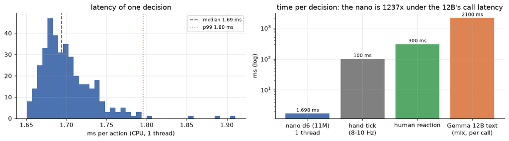

```python
speed = {th: bench(CKPT, n=300, threads=th) for th in (1, 4)}
for th, s in speed.items():
    print(f"threads {th}: {s['ms_per_action']:.2f} ms/action (policy), {s['wall_ms_per_action']:.2f} ms wall, {s['params_M']}M params")

# per-action latency distribution, 1 thread, on a real board
torch.set_num_threads(1)
seat = NanoSeat(CKPT, temperature=1.0, seed=0, threads=1)
seat.reset(BOARD)
lat = []
for _ in range(400):
    t0 = time.perf_counter(); seat.step(); lat.append((time.perf_counter() - t0) * 1000)
lat = np.array(lat[20:])
torch.set_num_threads(4)

fig, ax = plt.subplots(1, 2, figsize=(12, 3.4))
ax[0].hist(lat, bins=40, color="#4C72B0"); ax[0].axvline(np.median(lat), color="#C44E52", ls="--", label=f"median {np.median(lat):.2f} ms")
ax[0].axvline(np.percentile(lat, 99), color="#DD8452", ls=":", label=f"p99 {np.percentile(lat, 99):.2f} ms"); ax[0].legend(fontsize=8)
ax[0].set_xlabel("ms per action (CPU, 1 thread)"); ax[0].set_title("latency of one decision")
seats = ["nano d6 (11M)\n1 thread", "hand tick\n(8-10 Hz)", "human reaction", "Gemma 12B text\n(mlx, per call)"]
ms = [speed[1]["ms_per_action"], 100, 300, 2100]
ax[1].bar(seats, ms, color=["#4C72B0", "gray", "#55A868", "#DD8452"]); ax[1].set_yscale("log"); ax[1].set_ylabel("ms (log)")
for i, v in enumerate(ms): ax[1].text(i, v * 1.15, f"{v:g} ms", ha="center", fontsize=8)
ax[1].set_title(f"time per decision: the nano is {2100/speed[1]['ms_per_action']:.0f}x under the 12B's call latency")
plt.tight_layout(); plt.show()
```

### 4.1 Where would it start? The empty-path pointer and value

On an empty path the pointer head is "which tile to start from". Sweeping every tile as a one-letter prefix gives the value head's estimate of (P(\text{completes})) for each start; the solver's completion mass is shown beside it for the reader only.

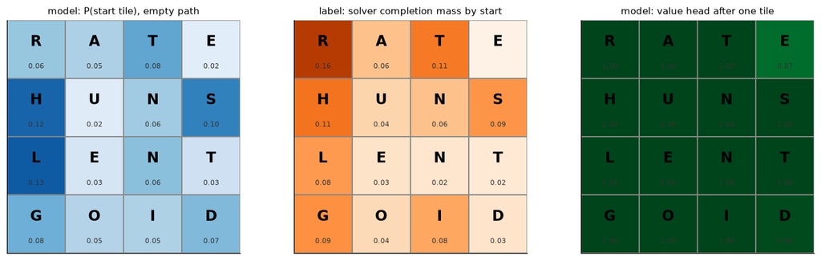

```
type dist on the empty path: {'extend': np.float32(1.0), 'submit': np.float32(0.0), 'abort': np.float32(0.0)}; value 1.00
pointer vs label: top-1 agree = False, L1 distance 0.39
```

```python
student = StudentPolicy(model, CPU, temperature=1.0, seed=0)
d0 = student.dists([BOARD], [()])[0]
one = student.dists([BOARD] * 16, [(i,) for i in range(16)])
val1 = np.array([d["value"] for d in one])
truth = np.zeros(16)
for t, m in info[()][1].items(): truth[t] = m
truth /= truth.sum()

fig, ax = plt.subplots(1, 3, figsize=(12.5, 3.8))
draw_board(ax[0], BOARD, title="model: P(start tile), empty path", tile_colors=d0["target"], cmap="Blues", vmin=0, vmax=d0["target"].max() * 1.2, annotate_vals=[f"{p:.2f}" if p > 0.005 else "" for p in d0["target"]])
draw_board(ax[1], BOARD, title="label: solver completion mass by start", tile_colors=truth, cmap="Oranges", vmin=0, vmax=truth.max() * 1.2, annotate_vals=[f"{p:.2f}" if p > 0.005 else "" for p in truth])
draw_board(ax[2], BOARD, title="model: value head after one tile", tile_colors=val1, cmap="Greens", vmin=0, vmax=1, annotate_vals=[f"{p:.2f}" for p in val1])
plt.tight_layout(); plt.show()
print(f"type dist on the empty path: {dict(zip(TYPES, np.round(d0['type'], 3)))}; value {d0['value']:.2f}")
print(f"pointer vs label: top-1 agree = {int(d0['target'].argmax()) == int(truth.argmax())}, L1 distance {np.abs(d0['target'] - truth).sum():.2f}")
```

## 5. Sample trajectories

`nano/rollout.py::play` runs a policy for a tick budget (600 actions = 75 s at 8 Hz) and scores it against the solver. Below is the same loop instrumented to keep every episode: the tile path, the value head at each step, and how it ended (`valid` submit, `invalid` submit of a non-word, `dup` re-submit of a word already found, or `abort`).

```python
def play_traced(board: str, policy, ticks: int = 600):
    policy.reset()
    words_on = solver.words_on(board)
    found: set[str] = set()
    episodes, cur = [], {"path": (), "values": [], "confs": []}
    for t in range(ticks):
        (atype, tile), inf = policy.act(board, cur["path"])
        cur["values"].append(float(inf.get("value", np.nan))); cur["confs"].append(float(inf.get("confidence", np.nan)))
        if atype == "extend" and tile >= 0:
            cur["path"] = cur["path"] + (tile,)
            continue
        w = path_word(board, cur["path"])
        if atype == "submit":
            end = "dup" if w in found else ("valid" if w in words_on else "invalid")
            if end == "valid": found.add(w)
        else:
            end = "abort"
        episodes.append({"tick": t, "word": w, "path": cur["path"], "end": end, "values": cur["values"], "confs": cur["confs"]})
        cur = {"path": (), "values": [], "confs": []}
    return {"board": board, "episodes": episodes, "found": found, "words_on": words_on, "score": sum(score_word(w) for w in found)}

student = StudentPolicy(model, CPU, temperature=1.0, seed=0)
tr1 = play_traced(BOARD, student, ticks=600)
eps = tr1["episodes"]
ends = {k: sum(e["end"] == k for e in eps) for k in ("valid", "invalid", "dup", "abort")}
print(f"board {BOARD!r}: {len(eps)} episodes in 600 actions; {ends}; found {len(tr1['found'])}/{len(tr1['words_on'])} words, score {tr1['score']} of {sum(score_word(w) for w in tr1['words_on'])}")
print("found:", sorted(tr1["found"], key=lambda w: (-len(w), w)))

print("\nfirst 24 episodes (tick, traced letters, outcome, value head along the path):")
for e in eps[:24]:
    vs = " ".join(f"{v:.2f}" for v in e["values"])
    print(f"  t{e['tick']:3d}  {e['word'].upper():<9} {e['end']:<8} value: {vs}")
```

```
board 'ratehunslentgoid': 130 episodes in 600 actions; {'valid': 51, 'invalid': 5, 'dup': 43, 'abort': 31}; found 51/220 words, score 13800 of 126700
found: ['annul', 'inset', 'tunes', 'dine', 'gene', 'gent', 'glue', 'gone', 'hant', 'hens', 'hunt', 'inns', 'lend', 'lens', 'lone', 'noel', 'nuts', 'rant', 'rule', 'sent', 'star', 'stun', 'test', 'tins', 'tune', 'ant', 'die', 'din', 'dit', 'end', 'eta', 'gen', 'hat', 'hen', 'hun', 'inn', 'its', 'leg'…

first 24 episodes (tick, traced letters, outcome, value head along the path):
  t  4  HANT      valid    value: 1.00 1.00 1.00 0.97 0.99
  t  9  GONE      valid    value: 1.00 1.00 1.00 0.99 0.97
  t 14  STAR      valid    value: 1.00 1.00 0.98 0.99 1.00
  t 19  NOEL      valid    value: 1.00 1.00 1.00 0.78 0.99
  t 23  INN       valid    value: 1.00 1.00 1.00 1.00
  t 27  NET       valid    value: 1.00 1.00 1.00 1.00
  t 32  HARU      abort    value: 1.00 1.00 1.00 0.76 0.01
  t 36  NET       dup      value: 1.00 1.00 1.00 1.00
  t 40  DIT       valid    value: 1.00 0.98 1.00 1.00
  t 45  SENT      valid    value: 1.00 1.00 1.00 1.00 1.00
  t 51  GOIND     invalid  value: 1.00 1.00 1.00 0.33 0.98 0.14
  t 55  DIT       dup      value: 1.00 0.98 1.00 1.00
  t 59  HEN       valid    value: 1.00 1.00 1.00 1.00
  t 63  RUE       valid    value: 1.00 1.00 1.00 1.00
  t 68  LUTE      abort    value: 1.00 1.00 0.99 0.79 0.04
  t 73  HENS      valid    value: 1.00 1.00 1.00 1.00 0.98
  t 78  LENS      valid    value: 1.00 1.00 1.00 0.97 1.00
  t 82  ONS       valid    value: 1.00 1.00 1.00 1.00
  t 87  GENT      valid    value: 1.00 1.00 1.00 1.00 1.00
  t 91  ONE       valid    value: 1.00 1.00 1.00 1.00
  t 96  HEND      invalid  value: 1.00 1.00 1.00 1.00 0.99
  t100  ONE       dup      value: 1.00 1.00 1.00 1.00
  t105  HUNT      valid    value: 1.00 1.00 1.00 1.00 0.98
  t111  ENTID     abort    value: 1.00 0.87 0.99 0.74 0.94 0.27
```

### 5.1 The finger on the board

The twelve longest distinct words the seat found on this board, drawn as the tile paths it actually traced (circle = start).

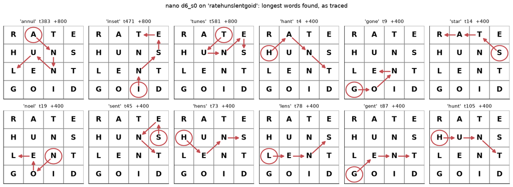

```python
valid_eps = {}
for e in eps:
    if e["end"] == "valid": valid_eps.setdefault(e["word"], e)
show = sorted(valid_eps.values(), key=lambda e: (-len(e["word"]), e["tick"]))[:12]
fig, ax = plt.subplots(2, 6, figsize=(15, 5.4))
for a, e in zip(ax.ravel(), show):
    draw_board(a, BOARD, e["path"], title=f"'{e['word']}'  t{e['tick']}  +{score_word(e['word'])}")
for a in ax.ravel()[len(show):]: a.axis("off")
plt.suptitle(f"nano d6_s0 on {BOARD!r}: longest words found, as traced", y=1.0); plt.tight_layout(); plt.show()
```

### 5.2 Hesitation: the value head along an episode

PLAN.md section 3 asks the seat to "hesitate, back out". The value head is that signal: it should fall as a path stops leading anywhere, and stay high when a word is forming. Left: value vs. step within the episode, coloured by how the episode ended. Right: how every episode ended, and how many actions each outcome costs.

Note the `dup` bar: the bare `StudentPolicy` (what `rollout.py` and the gate measure) has no memory, so it re-traces words it already has. In the match `NanoSeat` zeroes `submit` mass on accepted words (`on_result`), so the gate numbers are conservative for the seat that actually plays; the cell below the plot shows the difference on this board.

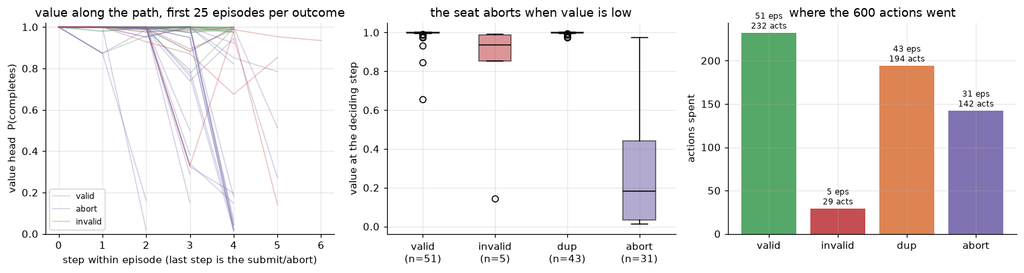

```
bare StudentPolicy: 51 words, score 13800, 43 duplicate submits
NanoSeat (dedup):   60 words, score 18300, valid rate 0.909, longest 'gents'
```

```python
cols = {"valid": "#55A868", "invalid": "#C44E52", "dup": "#DD8452", "abort": "#8172B2"}
fig, ax = plt.subplots(1, 3, figsize=(14, 3.8))
for end in ("valid", "abort", "invalid"):
    sel = [e for e in eps if e["end"] == end][:25]
    for i, e in enumerate(sel):
        ax[0].plot(range(len(e["values"])), e["values"], color=cols[end], alpha=0.35, lw=1, label=end if i == 0 else None)
ax[0].set_xlabel("step within episode (last step is the submit/abort)"); ax[0].set_ylabel("value head  P(completes)"); ax[0].set_ylim(0, 1.02)
ax[0].set_title("value along the path, first 25 episodes per outcome"); ax[0].legend(fontsize=8)
# mean value at the final step by outcome
final = {end: [e["values"][-1] for e in eps if e["end"] == end] for end in cols}
ax[1].boxplot([final[k] for k in cols if final[k]], tick_labels=[f"{k}\n(n={len(final[k])})" for k in cols if final[k]], patch_artist=True, medianprops={"color": "black"})
for patch, k in zip(ax[1].patches, [k for k in cols if final[k]]): patch.set_facecolor(cols[k]); patch.set_alpha(0.6)
ax[1].set_ylabel("value at the deciding step"); ax[1].set_title("the seat aborts when value is low")
lens = {end: [len(e["values"]) for e in eps if e["end"] == end] for end in cols}
ax[2].bar(list(cols), [sum(lens[k]) for k in cols], color=[cols[k] for k in cols])
for i, k in enumerate(cols): ax[2].text(i, sum(lens[k]) + 5, f"{len(lens[k])} eps\n{sum(lens[k])} acts", ha="center", fontsize=8)
ax[2].set_ylabel("actions spent"); ax[2].set_title("where the 600 actions went")
plt.tight_layout(); plt.show()

# same board, same 600 actions, through NanoSeat (remembers accepted words, so no re-tracing)
seat = NanoSeat(CKPT, temperature=1.0, seed=0, threads=1)
seat.reset(BOARD)
seat_found: set[str] = set(); seat_submits = seat_valid = 0
for _ in range(600):
    p_before = seat.path
    a = seat.step()
    if a[0] == "submit":
        seat_submits += 1
        w = path_word(BOARD, p_before)
        ok = w in tr1["words_on"]
        seat.on_result(w, ok)
        if ok: seat_valid += 1; seat_found.add(w)
torch.set_num_threads(4)
print(f"bare StudentPolicy: {len(tr1['found'])} words, score {tr1['score']}, {ends['dup']} duplicate submits")
print(f"NanoSeat (dedup):   {len(seat_found)} words, score {sum(score_word(w) for w in seat_found)}, valid rate {seat_valid/max(seat_submits,1):.3f}, "
      f"longest {max(seat_found, key=len)!r}")
```

### 5.3 What it finds vs. what is there, and two seats diverging

Left: the word-length profile of what the seat found against everything the solver knows is on the board. This is the honest caveat on the slide: volume of 3-4 letter words, few 5s, no 7s. Right: two seats with different sampling seeds on the same boards find overlapping but different word sets (Jaccard overlap), which is why two nanos on one board look like two players.

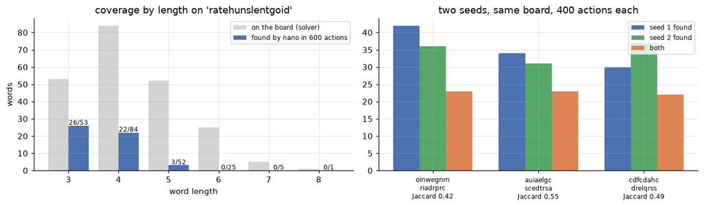

```python
avail = np.bincount([len(w) for w in tr1["words_on"]], minlength=MAX_LEN + 1)[MIN_LEN:]
got = np.bincount([len(w) for w in tr1["found"]], minlength=MAX_LEN + 1)[MIN_LEN:]
L = np.arange(MIN_LEN, MAX_LEN + 1)

boards_div = []
rng = np.random.default_rng(777)
while len(boards_div) < 3:
    b = random_board(rng, letter_p)
    if len(solver.words_on(b)) >= 15: boards_div.append(b)
pairs = []
for b in boards_div:
    fa = play(b, StudentPolicy(model, CPU, 1.0, seed=1), solver, 400)["found"]
    fb = play(b, StudentPolicy(model, CPU, 1.0, seed=2), solver, 400)["found"]
    sa, sb = set(fa), set(fb)
    pairs.append((b, len(sa), len(sb), len(sa & sb), len(sa | sb)))

fig, ax = plt.subplots(1, 2, figsize=(12, 3.6))
ax[0].bar(L - 0.2, avail, 0.4, label="on the board (solver)", color="lightgray"); ax[0].bar(L + 0.2, got, 0.4, label="found by nano in 600 actions", color="#4C72B0")
for i, (a, g) in enumerate(zip(avail, got)):
    if a: ax[0].text(L[i] + 0.2, g + 0.5, f"{g}/{a}", ha="center", fontsize=8)
ax[0].set_xlabel("word length"); ax[0].set_ylabel("words"); ax[0].set_title(f"coverage by length on {BOARD!r}"); ax[0].legend(fontsize=8)
x = np.arange(len(pairs))
ax[1].bar(x - 0.25, [p[1] for p in pairs], 0.25, label="seed 1 found", color="#4C72B0"); ax[1].bar(x, [p[2] for p in pairs], 0.25, label="seed 2 found", color="#55A868"); ax[1].bar(x + 0.25, [p[3] for p in pairs], 0.25, label="both", color="#DD8452")
ax[1].set_xticks(x); ax[1].set_xticklabels([f"{p[0][:8]}\n{p[0][8:]}\nJaccard {p[3]/max(p[4],1):.2f}" for p in pairs], fontsize=8); ax[1].set_title("two seeds, same board, 400 actions each"); ax[1].legend(fontsize=8)
plt.tight_layout(); plt.show()
```

## 6. Gate and league (recorded)

The gate was pre-registered in PLAN.md section 3 before training: on 50 unseen boards, score (\ge 4\times) a random swiper **and** a higher valid-submit rate than the Gemma E4B seat (proxy today: the Gemma 4 12B text-grid seat, 0.20 valid on (n=20), `gemma_seat/results/eval_n20_seed0.md`). `python -m nano.gate` wrote `nano/results/gate_d6_s0.{md,json}`.

```
verdict PASS: score 9126 vs random 952 = 9.59x (>= 4x); valid rate 0.971 vs Gemma proxy 0.20; 38.0 words/board, mean len 3.44, longest 'stokes'; 1.906 ms/action
```

```
replayed 12 gate boards in 15s: nano 8342 vs random 925 per board
```

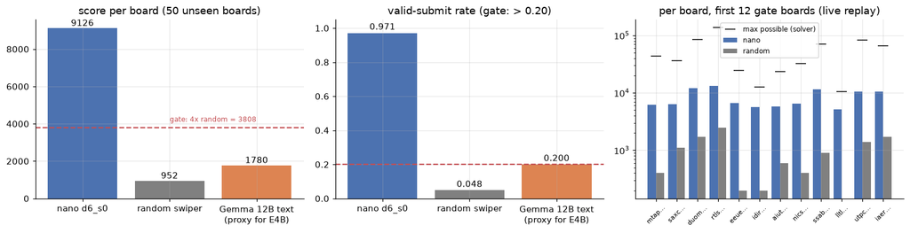

```
word-length histogram over the 50 gate boards: {3: 1139, 4: 676, 5: 83, 6: 4, 7: 0, 8: 0} -> 1902 valid words, 95% are 3-4 letters
```

```python
G = json.load(open("nano/results/gate_d6_s0.json"))
S, R = G["student"], G["random"]
print(f"verdict {G['verdict']}: score {S['score_mean']:.0f} vs random {R['score_mean']:.0f} = {G['ratio']:.2f}x (>= 4x); "
      f"valid rate {S['valid_rate']:.3f} vs Gemma proxy 0.20; {S['found_mean']:.1f} words/board, mean len {S['mean_len']:.2f}, longest {S['longest']!r}; "
      f"{G['speed']['ms_per_action']} ms/action")

# per-board comparison, replayed live on the first 12 gate boards (the JSON keeps only the summaries)
gate_boards = G["boards"][:12]
st = StudentPolicy(model, CPU, temperature=1.0, seed=G["args"]["seed"])
rd = RandomSwiper(seed=G["args"]["seed"])
t0 = time.time()
rows_s = [play(b, st, solver, 600) for b in gate_boards]
rows_r = [play(b, rd, solver, 600) for b in gate_boards]
print(f"replayed {len(gate_boards)} gate boards in {time.time()-t0:.0f}s: nano {np.mean([r['score'] for r in rows_s]):.0f} vs random {np.mean([r['score'] for r in rows_r]):.0f} per board")

fig, ax = plt.subplots(1, 3, figsize=(14.5, 3.8))
labels = ["nano d6_s0", "random swiper", "Gemma 12B text\n(proxy for E4B)"]
scores = [S["score_mean"], R["score_mean"], 1780]; valid = [S["valid_rate"], R["valid_rate"], 0.20]
c3 = ["#4C72B0", "gray", "#DD8452"]
ax[0].bar(labels, scores, color=c3); ax[0].axhline(4 * R["score_mean"], ls="--", color="#C44E52"); ax[0].text(1.5, 4 * R["score_mean"] * 1.08, f"gate: 4x random = {4*R['score_mean']:.0f}", color="#C44E52", fontsize=8, ha="center")
for i, v in enumerate(scores): ax[0].text(i, v + 120, f"{v:.0f}", ha="center")
ax[0].set_title("score per board (50 unseen boards)")
ax[1].bar(labels, valid, color=c3); ax[1].axhline(0.20, ls="--", color="#C44E52"); ax[1].set_ylim(0, 1.05); ax[1].set_title("valid-submit rate (gate: > 0.20)")
for i, v in enumerate(valid): ax[1].text(i, v + 0.02, f"{v:.3f}", ha="center")
xs = np.arange(len(gate_boards))
ax[2].bar(xs - 0.2, [r["score"] for r in rows_s], 0.4, color="#4C72B0", label="nano"); ax[2].bar(xs + 0.2, [r["score"] for r in rows_r], 0.4, color="gray", label="random")
ax[2].plot(xs, [r["max_score"] for r in rows_s], "k_", ms=12, label="max possible (solver)")
ax[2].set_yscale("log"); ax[2].set_xticks(xs); ax[2].set_xticklabels([b[:4] + "…" for b in gate_boards], fontsize=7, rotation=45); ax[2].set_title("per board, first 12 gate boards (live replay)"); ax[2].legend(fontsize=8)
plt.tight_layout(); plt.show()

hist = {3: 1139, 4: 676, 5: 83, 6: 4, 7: 0, 8: 0}  # word-length histogram from gate_d6_s0.md (all 50 boards)
print("word-length histogram over the 50 gate boards:", hist, f"-> {sum(hist.values())} valid words, {100*(hist[3]+hist[4])/sum(hist.values()):.0f}% are 3-4 letters")
```

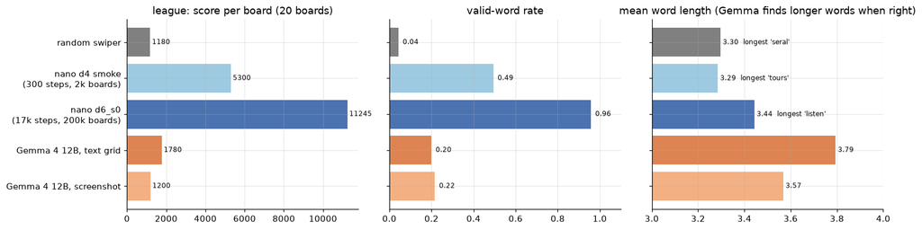

```
random swiper                                 score   1180  valid 0.04  len 3.30  wpm 4.5  0 ms                         0
nano d4 smoke (300 steps, 2k boards)          score   5300  valid 0.49  len 3.29  wpm 22.1  0.8 ms / action              3.3M
nano d6_s0 (17k steps, 200k boards)           score  11245  valid 0.96  len 3.44  wpm 36.1  2.7 ms / action              11.0M
Gemma 4 12B, text grid                        score   1780  valid 0.20  len 3.79  wpm 27.7  2.1 s / call (~26 words)     12B (4-bit)
Gemma 4 12B, screenshot                       score   1200  valid 0.22  len 3.57  wpm 28.5  2.2 s / call (~20 words)     12B (4-bit)
```

```python
# the 20-board AI-only league, docs/league.json (Gemma rows are recorded one-call-per-board evals)
LG = json.load(open("docs/league.json"))
rows = LG["rows"]
clean = lambda s: re.sub(r"\*", "", s)
fig, ax = plt.subplots(1, 3, figsize=(14.5, 3.8))
names = [clean(r["seat"]).replace(" (", "\n(") for r in rows]
colors = ["gray", "#9ecae1", "#4C72B0", "#DD8452", "#f3b083"]
ax[0].barh(names, [r["score"] for r in rows], color=colors); ax[0].invert_yaxis(); ax[0].set_title("league: score per board (20 boards)")
for i, r in enumerate(rows): ax[0].text(r["score"] + 100, i, f"{r['score']:.0f}", va="center", fontsize=8)
ax[1].barh(names, [r["valid_rate"] for r in rows], color=colors); ax[1].invert_yaxis(); ax[1].set_xlim(0, 1.1); ax[1].set_title("valid-word rate"); ax[1].set_yticklabels([])
for i, r in enumerate(rows): ax[1].text(r["valid_rate"] + 0.02, i, f"{r['valid_rate']:.2f}", va="center", fontsize=8)
ax[2].barh(names, [r["mean_len"] for r in rows], color=colors); ax[2].invert_yaxis(); ax[2].set_xlim(3, 4); ax[2].set_title("mean word length (Gemma finds longer words when right)"); ax[2].set_yticklabels([])
for i, r in enumerate(rows): ax[2].text(r["mean_len"] + 0.01, i, f"{r['mean_len']:.2f}" + (f"  longest {r['longest']!r}" if r.get("longest") else ""), va="center", fontsize=8)
plt.tight_layout(); plt.show()
for r in rows: print(f"{clean(r['seat']):<45} score {r['score']:>6.0f}  valid {r['valid_rate']:.2f}  len {r['mean_len']:.2f}  wpm {r['wpm']:.1f}  {r['latency']:<28} {r['params']}")
```

## 7. Live learning between rounds

The thesis line (PLAN.md section 3): every validated word from any seat, human or Gemma, goes into a CPU update during the 20 s rematch countdown. `nano/learn.py::OnlineLearner.update` converts the round's words into the same soft targets as `data.py` (restricted to the known words, no dead mining), blends them 0.5/0.5 with the model's own predictions (hinted self-distillation, so 15 words cannot rewrite a 200k-board prior), runs 50 BC steps at lr (2\times10^{-5}) mixed 1:1 with replay from the base distribution, replays a fixed 20-board held-out set under common random numbers, and **rolls back** if the held-out score drops more than 3%.

### 7.1 The recorded 10-round curve

`python -m nano.learn --rounds 10` with the solver's top-15 common words (length (\ge 4)) standing in for Gemma as the teacher.

```
parsed 11 rows; kept 8/10 updates; held-out 7160 -> 7145; recall mean 0.35 -> 0.46; update wall mean 9.6s
```

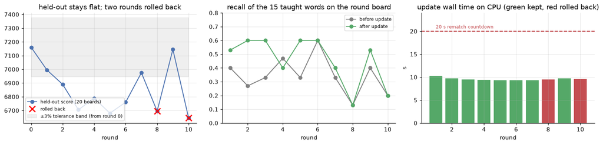

```python
txt = open("nano/results/live_learning_curve.md").read()
rows_ll = []
for line in txt.splitlines():
    m = re.match(r"\|\s*(\d+)\s*\|\s*(yes|rollback)\s*\|\s*(\d+)\s*\|\s*([\d.]+)\s*\|\s*([\d.]+)\s*\|\s*(\d+)\s*\|\s*(?:([\d.]+) -> ([\d.]+))?\s*\|\s*([\d.]+)", line)
    if m:
        r_, kept, ho, wpb, vr, taught, rb, ra, sec = m.groups()
        rows_ll.append({"round": int(r_), "kept": kept == "yes", "held_out": float(ho), "words": float(wpb), "valid": float(vr), "taught": int(taught),
                        "recall_before": float(rb) if rb else None, "recall_after": float(ra) if ra else None, "seconds": float(sec)})
print(f"parsed {len(rows_ll)} rows; kept {sum(r['kept'] for r in rows_ll[1:])}/{len(rows_ll)-1} updates; "
      f"held-out {rows_ll[0]['held_out']:.0f} -> {[r for r in rows_ll if r['kept']][-1]['held_out']:.0f}; "
      f"recall mean {np.mean([r['recall_before'] for r in rows_ll[1:]]):.2f} -> {np.mean([r['recall_after'] for r in rows_ll[1:]]):.2f}; "
      f"update wall mean {np.mean([r['seconds'] for r in rows_ll[1:]]):.1f}s")

fig, ax = plt.subplots(1, 3, figsize=(14.5, 3.6))
rr = [r["round"] for r in rows_ll]
ax[0].plot(rr, [r["held_out"] for r in rows_ll], "o-", color="#4C72B0", label="held-out score (20 boards)")
for r in rows_ll[1:]:
    if not r["kept"]: ax[0].plot(r["round"], r["held_out"], "rx", ms=11, mew=2, label="rolled back" if r["round"] == [q["round"] for q in rows_ll if not q["kept"]][0] else None)
ax[0].fill_between(rr, rows_ll[0]["held_out"] * 0.97, rows_ll[0]["held_out"] * 1.03, color="gray", alpha=0.12, label="±3% tolerance band (from round 0)")
ax[0].set_xlabel("round"); ax[0].set_title("held-out stays flat; two rounds rolled back"); ax[0].legend(fontsize=8)
ax[1].plot(rr[1:], [r["recall_before"] for r in rows_ll[1:]], "o-", color="gray", label="before update")
ax[1].plot(rr[1:], [r["recall_after"] for r in rows_ll[1:]], "o-", color="#55A868", label="after update")
ax[1].set_ylim(0, 0.8); ax[1].set_xlabel("round"); ax[1].set_title("recall of the 15 taught words on the round board"); ax[1].legend(fontsize=8)
ax[2].bar(rr[1:], [r["seconds"] for r in rows_ll[1:]], color=["#55A868" if r["kept"] else "#C44E52" for r in rows_ll[1:]])
ax[2].axhline(20, ls="--", color="#C44E52"); ax[2].text(1, 20.6, "20 s rematch countdown", color="#C44E52", fontsize=8)
ax[2].set_ylim(0, 24); ax[2].set_xlabel("round"); ax[2].set_ylabel("s"); ax[2].set_title("update wall time on CPU (green kept, red rolled back)")
plt.tight_layout(); plt.show()
```

### 7.2 Three rounds, live

`simulate()` run here for three rounds against the same solver-as-teacher stand-in. There is no `data/wh_200000.npz` on this machine, so the learner generates its 400 replay boards at construction (that is most of the setup time). Numbers move with the seed; the point is the mechanism: update → held-out check → keep or roll back, inside the budget.

```python
from nano.learn import simulate
t0 = time.time()
live_rows = simulate(CKPT, rounds=3, out=None, seed=41_000)
print(f"\n{time.time()-t0:.0f}s total including learner construction")
for r in live_rows[1:]:
    print(f"round {r['round']}: {'KEEP' if r['kept'] else 'ROLLBACK'}  held-out {r['held_out_before']:.0f} -> {r['held_out_after']:.0f}  "
          f"taught {r['taught']} words {r['words'][:6]}...  recall {r['recall_before']:.2f} -> {r['recall_after']:.2f}  {r['seconds']:.1f}s")
```

```
round 0 held-out 7160 (30.0 words, valid 0.976) eval 4.1s
```

```
round 1 KEEP held-out 7160 -> 6990  taught 15 recall 0.47 -> 0.60  loss 0.973->0.983  9.7s (train 5.4s)
```

```
round 2 ROLLBACK held-out 6990 -> 6765  taught 15 recall 0.47 -> 0.47  loss 0.934->0.953  9.9s (train 5.6s)
```

```
round 3 KEEP held-out 6990 -> 7170  taught 15 recall 0.20 -> 0.53  loss 1.017->0.933  9.7s (train 5.5s)

38s total including learner construction
round 1: KEEP  held-out 7160 -> 6990  taught 15 words ['life', 'fear', 'pearl', 'seal', 'spears', 'oops']...  recall 0.47 -> 0.60  9.7s
round 2: ROLLBACK  held-out 6990 -> 6765  taught 15 words ['also', 'done', 'adult', 'uses', 'ones', 'soul']...  recall 0.47 -> 0.47  9.9s
round 3: KEEP  held-out 6990 -> 7170  taught 15 words ['rules', 'else', 'seen', 'rule', 'lies', 'burn']...  recall 0.20 -> 0.53  9.7s
```

## 8. Summary and open items

**The three stage numbers, as measured in this notebook and its recorded artifacts**

1. *11M parameters, zero tokens, ~2 ms a move.* Depth-6 transformer over 26 fixed tokens; pointer/type/value heads; no dictionary at inference. 17,278 steps × 256 on 200k self-solved boards in 30 min on MPS; `bench()` above on this CPU.
2. *Gate passed at 9.6x, 97% valid.* Pre-registered before training; 50 unseen boards; 9126 vs 952 per board against the random swiper, 0.971 valid-submit rate against the Gemma proxy's 0.20. League on 20 boards: nano 11245, 12B text 1780.
3. *It learns the words it was just shown.* 8/10 updates kept in ~9.5 s each; taught-word recall 0.35 → 0.46 while held-out moved −0.2%. It does not get better at Word Hunt in ten rounds; say exactly that.

**Next runs, in order:** second seed for the gate spread; longer budget (60 min) on the same data; a length-aware sampling temperature or a bonus on `submit` for ≥5-letter prefixes if the long-word gap matters on stage; human boards for the stretch target (≥ 60% of human median) once the room has rounds.